# Homework 2 of CS 422: Section 04

Diego Martin Crespo, A20432558

## 2.1 Decision tree classification

First we set the seeds

```r
set.seed(1122)
```

Now we proceed by reading the adult train and test dataset. From the description in the homework we see that they are all factors, so we leave the default, which is true.

```r
adult_train<-read.csv("../adult-train.csv", header=TRUE, sep=',')
adult_test<-read.csv("../adult-test.csv", header=TRUE, sep=',')
str(adult_train) #we check that the attributes are from the correct type
```

```
'data.frame':   32560 obs. of  15 variables:
 $ age           : int  39 50 38 53 28 37 49 52 31 42 ...
 $ workclass     : Factor w/ 9 levels "?","Federal-gov",..: 8 7 5 5 5 5 5 7 5 5 ...
 $ fnlwgt        : int  77516 83311 215646 234721 338409 284582 160187 209642 45781 159449 ...
 $ education     : Factor w/ 16 levels "10th","11th",..: 10 10 12 2 10 13 7 12 13 10 ...
 $ education_num : int  13 13 9 7 13 14 5 9 14 13 ...
 $ marital_status: Factor w/ 7 levels "Divorced","Married-AF-spouse",..: 5 3 1 3 3 3 4 3 5 3 ...
 $ occupation    : Factor w/ 15 levels "?","Adm-clerical",..: 2 5 7 7 11 5 9 5 11 5 ...
 $ relationship  : Factor w/ 6 levels "Husband","Not-in-family",..: 2 1 2 1 6 6 2 1 2 1 ...
 $ race          : Factor w/ 5 levels "Amer-Indian-Eskimo",..: 5 5 5 3 3 5 3 5 5 5 ...
 $ sex           : Factor w/ 2 levels "Female","Male": 2 2 2 2 1 1 1 2 1 2 ...
 $ capital_gain  : int  2174 0 0 0 0 0 0 0 14084 5178 ...
 $ capital_loss  : int  0 0 0 0 0 0 0 0 0 0 ...
 $ hours_per_week: int  40 13 40 40 40 40 16 45 50 40 ...
 $ native_country: Factor w/ 41 levels "?","Cambodia",..: 39 39 39 39 6 39 23 39 39 39 ...
 $ income        : Factor w/ 2 levels "<=50K",">50K": 1 1 1 1 1 1 1 2 2 2 ...
```

```r
str(adult_test)
```

```
'data.frame':   16281 obs. of  15 variables:
 $ age           : int  25 38 28 44 18 34 29 63 24 55 ...
 $ workclass     : Factor w/ 9 levels "?","Federal-gov",..: 5 5 3 5 1 5 1 7 5 5 ...
 $ fnlwgt        : int  226802 89814 336951 160323 103497 198693 227026 104626 369667 104996 ...
 $ education     : Factor w/ 16 levels "10th","11th",..: 2 12 8 16 16 1 12 15 16 6 ...
 $ education_num : int  7 9 12 10 10 6 9 15 10 4 ...
 $ marital_status: Factor w/ 7 levels "Divorced","Married-AF-spouse",..: 5 3 3 3 5 5 5 3 5 3 ...
 $ occupation    : Factor w/ 15 levels "?","Adm-clerical",..: 8 6 12 8 1 9 1 11 9 4 ...
 $ relationship  : Factor w/ 6 levels "Husband","Not-in-family",..: 4 1 1 1 4 2 5 1 5 1 ...
 $ race          : Factor w/ 5 levels "Amer-Indian-Eskimo",..: 3 5 5 3 5 5 3 5 5 5 ...
 $ sex           : Factor w/ 2 levels "Female","Male": 2 2 2 2 1 2 2 2 1 2 ...
 $ capital_gain  : int  0 0 0 7688 0 0 0 3103 0 0 ...
 $ capital_loss  : int  0 0 0 0 0 0 0 0 0 0 ...
 $ hours_per_week: int  40 50 40 40 30 30 40 32 40 10 ...
 $ native_country: Factor w/ 41 levels "?","Cambodia",..: 39 39 39 39 39 39 39 39 39 39 ...
 $ income        : Factor w/ 2 levels "<=50K",">50K": 1 1 2 2 1 1 1 2 1 1 ...
```

```r
adult_train$age<-as.numeric(adult_train$age)
adult_train$education_num<-as.numeric(adult_train$education_num)
adult_test$age<-as.numeric(adult_test$age)
adult_test$education_num<-as.numeric(adult_test$education_num)
```

### a) Remove ‘?’ from any of the attributes.

```r
summary(adult_train=='?') #we can see where the question marks are
```

```
    age          workclass         fnlwgt        education       education_num   marital_status  occupation      relationship
 Mode :logical   Mode :logical   Mode :logical   Mode :logical   Mode :logical   Mode :logical   Mode :logical   Mode :logical
 FALSE:32560     FALSE:30724     FALSE:32560     FALSE:32560     FALSE:32560     FALSE:32560     FALSE:30717     FALSE:32560
                 TRUE :1836                                                                      TRUE :1843
    race            sex          capital_gain    capital_loss    hours_per_week  native_country    income
 Mode :logical   Mode :logical   Mode :logical   Mode :logical   Mode :logical   Mode :logical   Mode :logical
 FALSE:32560     FALSE:32560     FALSE:32560     FALSE:32560     FALSE:32560     FALSE:31977     FALSE:32560
                                                                                 TRUE :583
```

From this we see that the attributes that have ‘?’ are workclass, native_country and occupation. Therefore we clean those atributes.

```r
sum(adult_train$workclass=='?')
```

```
[1] 1836
```

```r
index<-which(adult_train$workclass=='?')
adult_train<-adult_train[-index,]
sum(adult_train$native_country=='?')
```

```
[1] 556
```

```r
index<-which(adult_train$native_country=='?')
adult_train<-adult_train[-index,]
sum(adult_train$occupation=='?')
```

```
[1] 7
```

```r
index<-which(adult_train$occupation=='?')
adult_train<-adult_train[-index,]
```

We check to see if there are any values that we missed. It should be 30,161 observations as the problem statement says.

```r
sum(adult_train=='?')
```

```
[1] 0
```

```r
str(adult_train)
```

```
'data.frame':   30161 obs. of  15 variables:
 $ age           : num  39 50 38 53 28 37 49 52 31 42 ...
 $ workclass     : Factor w/ 9 levels "?","Federal-gov",..: 8 7 5 5 5 5 5 7 5 5 ...
 $ fnlwgt        : int  77516 83311 215646 234721 338409 284582 160187 209642 45781 159449 ...
 $ education     : Factor w/ 16 levels "10th","11th",..: 10 10 12 2 10 13 7 12 13 10 ...
 $ education_num : num  13 13 9 7 13 14 5 9 14 13 ...
 $ marital_status: Factor w/ 7 levels "Divorced","Married-AF-spouse",..: 5 3 1 3 3 3 4 3 5 3 ...
 $ occupation    : Factor w/ 15 levels "?","Adm-clerical",..: 2 5 7 7 11 5 9 5 11 5 ...
 $ relationship  : Factor w/ 6 levels "Husband","Not-in-family",..: 2 1 2 1 6 6 2 1 2 1 ...
 $ race          : Factor w/ 5 levels "Amer-Indian-Eskimo",..: 5 5 5 3 3 5 3 5 5 5 ...
 $ sex           : Factor w/ 2 levels "Female","Male": 2 2 2 2 1 1 1 2 1 2 ...
 $ capital_gain  : int  2174 0 0 0 0 0 0 0 14084 5178 ...
 $ capital_loss  : int  0 0 0 0 0 0 0 0 0 0 ...
 $ hours_per_week: int  40 13 40 40 40 40 16 45 50 40 ...
 $ native_country: Factor w/ 41 levels "?","Cambodia",..: 39 39 39 39 6 39 23 39 39 39 ...
 $ income        : Factor w/ 2 levels "<=50K",">50K": 1 1 1 1 1 1 1 2 2 2 ...
```

Now we continue cleaning the test dataset.

```r
summary(adult_test=='?') #esto creo que no lo puedo hacer
```

```
    age          workclass         fnlwgt        education       education_num   marital_status  occupation      relationship
 Mode :logical   Mode :logical   Mode :logical   Mode :logical   Mode :logical   Mode :logical   Mode :logical   Mode :logical
 FALSE:16281     FALSE:15318     FALSE:16281     FALSE:16281     FALSE:16281     FALSE:16281     FALSE:15315     FALSE:16281
                 TRUE :963                                                                       TRUE :966
    race            sex          capital_gain    capital_loss    hours_per_week  native_country    income
 Mode :logical   Mode :logical   Mode :logical   Mode :logical   Mode :logical   Mode :logical   Mode :logical
 FALSE:16281     FALSE:16281     FALSE:16281     FALSE:16281     FALSE:16281     FALSE:16007     FALSE:16281
                                                                                 TRUE :274
```

We start cleaning the dataset with the attributes that we know have ‘?’:

```r
sum(adult_test$workclass=='?')
```

```
[1] 963
```

```r
index<-which(adult_test$workclass=='?')
adult_test<-adult_test[-index,]
sum(adult_test$native_country=='?')
```

```
[1] 255
```

```r
index<-which(adult_test$native_country=='?')
adult_test<-adult_test[-index,]
sum(adult_test$occupation=='?')
```

```
[1] 3
```

```r
index<-which(adult_test$occupation=='?')
adult_test<-adult_test[-index,]
```

We check to see if there are any values that we missed. It should be 15,060 observations as the problem statement says.

```r
sum(adult_test=='?')
```

```
[1] 0
```

```r
str(adult_test)
```

```
'data.frame':   15060 obs. of  15 variables:
 $ age           : num  25 38 28 44 34 63 24 55 65 36 ...
 $ workclass     : Factor w/ 9 levels "?","Federal-gov",..: 5 5 3 5 5 7 5 5 5 2 ...
 $ fnlwgt        : int  226802 89814 336951 160323 198693 104626 369667 104996 184454 212465 ...
 $ education     : Factor w/ 16 levels "10th","11th",..: 2 12 8 16 1 15 16 6 12 10 ...
 $ education_num : num  7 9 12 10 6 15 10 4 9 13 ...
 $ marital_status: Factor w/ 7 levels "Divorced","Married-AF-spouse",..: 5 3 3 3 5 3 5 3 3 3 ...
 $ occupation    : Factor w/ 15 levels "?","Adm-clerical",..: 8 6 12 8 9 11 9 4 8 2 ...
 $ relationship  : Factor w/ 6 levels "Husband","Not-in-family",..: 4 1 1 1 2 1 5 1 1 1 ...
 $ race          : Factor w/ 5 levels "Amer-Indian-Eskimo",..: 3 5 5 3 5 5 5 5 5 5 ...
 $ sex           : Factor w/ 2 levels "Female","Male": 2 2 2 2 2 2 1 2 2 2 ...
 $ capital_gain  : int  0 0 0 7688 0 3103 0 0 6418 0 ...
 $ capital_loss  : int  0 0 0 0 0 0 0 0 0 0 ...
 $ hours_per_week: int  40 50 40 40 30 32 40 10 40 40 ...
 $ native_country: Factor w/ 41 levels "?","Cambodia",..: 39 39 39 39 39 39 39 39 39 39 ...
 $ income        : Factor w/ 2 levels "<=50K",">50K": 1 1 2 2 1 2 1 1 2 1 ...
```

Now that the datasets are cleaned we can continue with the exercise.

### b) Build a decision tree

```r
library(rpart)
library(caret)
library(gplots)
library(rpart.plot)
library(ROCR)
```

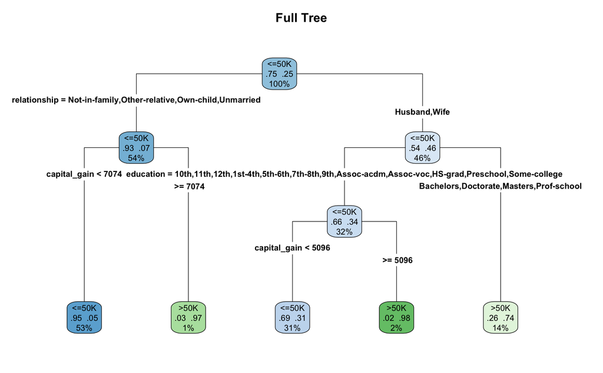

```r
model<-rpart(income~., method="class", data=adult_train)
rpart.plot(model, type=4, extra=104, fallen.leaves=TRUE, main="Full Tree")
```

#### i) the top three predictors are: “relationship, marrial_status and capital_gain”

#### ii) The first split is done in relationship. The predicted class of the first node is “<=50K”. There are 22653 counts for “<=50K” and 7508 counts for “>50K”.

```r
summary(model)
```

```
Call:
rpart(formula = income ~ ., data = adult_train, method = "class")
  n= 30161

          CP nsplit rel error    xerror        xstd
1 0.12999467      0 1.0000000 1.0000000 0.010001793
2 0.06419819      2 0.7400107 0.7400107 0.008966969
3 0.03729355      3 0.6758125 0.6758125 0.008652716
4 0.01000000      4 0.6385189 0.6385189 0.008457392

Variable importance
  relationship marital_status   capital_gain      education  education_num            sex     occupation            age hours_per_week
            24             23             10              9              9              8              7              5              3

Node number 1: 30161 observations,    complexity param=0.1299947
  predicted class=<=50K  expected loss=0.2489307  P(node) =1
    class counts: 22653  7508
   probabilities: 0.751 0.249
  left son=2 (16292 obs) right son=3 (13869 obs)
  Primary splits:
      relationship   splits as  RLLLLR, improve=2277.164, (0 missing)
      marital_status splits as  LRRLLLL, improve=2244.398, (0 missing)
      capital_gain   < 5119   to the left,  improve=1540.825, (0 missing)
      education      splits as  LLLLLLLLLRRLRLRL, improve=1193.769, (0 missing)
      education_num  < 12.5   to the left,  improve=1193.769, (0 missing)
  Surrogate splits:
      marital_status splits as  LRRLLLL, agree=0.993, adj=0.984, (0 split)
      sex            splits as  LR, agree=0.691, adj=0.328, (0 split)
      age            < 33.5   to the left,  agree=0.645, adj=0.229, (0 split)
      occupation     splits as  -LLRRRLLLLRRLLR, agree=0.620, adj=0.175, (0 split)
      hours_per_week < 43.5   to the left,  agree=0.604, adj=0.138, (0 split)

Node number 2: 16292 observations,    complexity param=0.03729355
  predicted class=<=50K  expected loss=0.06966609  P(node) =0.5401678
    class counts: 15157  1135
   probabilities: 0.930 0.070
  left son=4 (15992 obs) right son=5 (300 obs)
  Primary splits:
      capital_gain   < 7073.5 to the left,  improve=491.8224, (0 missing)
      education      splits as  LLLLLLLLLLRLRLRL, improve=142.9961, (0 missing)
```

[output cut: 43 more lines]

```

Node number 7: 4150 observations
  predicted class=>50K   expected loss=0.2648193  P(node) =0.1375949
    class counts:  1099  3051
   probabilities: 0.265 0.735

Node number 12: 9219 observations
  predicted class=<=50K  expected loss=0.3070832  P(node) =0.3056596
    class counts:  6388  2831
   probabilities: 0.693 0.307

Node number 13: 500 observations
  predicted class=>50K   expected loss=0.018  P(node) =0.0165777
    class counts:     9   491
   probabilities: 0.018 0.982
```

### c) Use the trained model from b) to predict the test dataset.

```r
options("digits"=3) #3 decimal place accuracy
pred<-predict(model, adult_test, type="class" )
confusionMatrix(pred, as.factor(adult_test[,15])) #the label is on the 15th column
```

```
Confusion Matrix and Statistics

          Reference
Prediction <=50K  >50K
     <=50K 10772  1837
     >50K    588  1863

               Accuracy : 0.839
                 95% CI : (0.833, 0.845)
    No Information Rate : 0.754
    P-Value [Acc > NIR] : <2e-16

                  Kappa : 0.51
 Mcnemar's Test P-Value : <2e-16

            Sensitivity : 0.948
            Specificity : 0.504
         Pos Pred Value : 0.854
         Neg Pred Value : 0.760
             Prevalence : 0.754
         Detection Rate : 0.715
   Detection Prevalence : 0.837
      Balanced Accuracy : 0.726

       'Positive' Class : <=50K
```

#### i) Since there are more examples in the ‘<=50K’ label than in the ‘>50k’ we have to look at the balanced accuracy. In this case its value is 0.726.

#### ii) Error = 1 - Balanced accuracy. If we substitute the values, we obtain that the error is 0.274

#### iii) Sensitivity = 0.948 this is the ratio of true positives/(true positives +false negatives). Specificity= 0.504 this is a measure of the true negative ratio. It is calculated by true negatives/(true negatives + false positives)

#### iv) The AUC of the ROC curve is 0.843

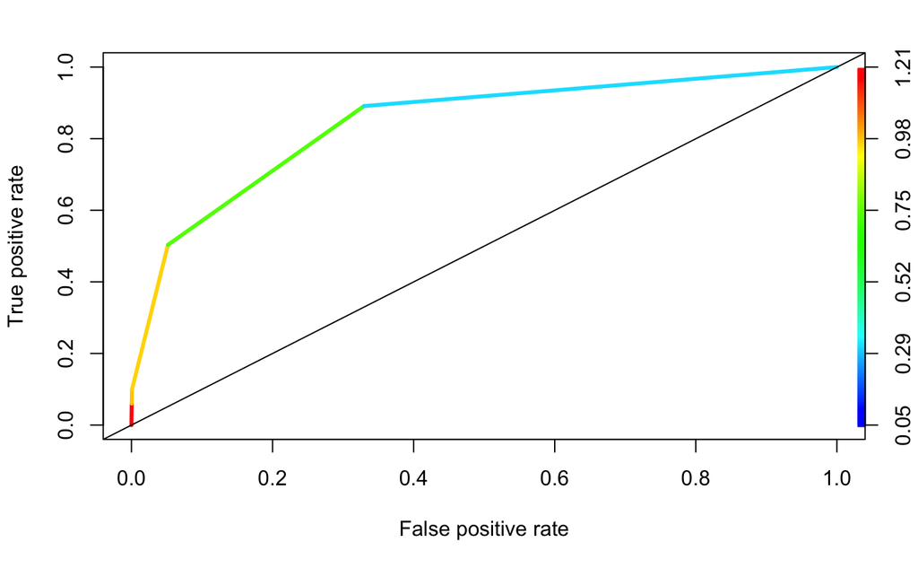

```r
pred.rocr <- predict(model, adult_test, type="prob")[,2]
f.pred <- prediction(pred.rocr, adult_test$income)
f.perf <- performance(f.pred, "tpr", "fpr")
plot(f.perf, colorize=T, lwd=3)
abline(0,1)
```

```r
auc <- performance(f.pred, measure = "auc")
```

```r
print(auc@y.values)
```

```
[[1]]
[1] 0.843
```

### d) Print the complexity table of the model you trained.

```r
model$cptable
```

```
      CP nsplit rel error xerror    xstd
1 0.1300      0     1.000  1.000 0.01000
2 0.0642      2     0.740  0.740 0.00897
3 0.0373      3     0.676  0.676 0.00865
4 0.0100      4     0.639  0.639 0.00846
```

#### From the complexity table we can see that there is no need for pruning, since the error we obtain for 4 levels is smaller than that obtained for 3 levels.

### e) Solve the class imbalance

#### i)

```r
nclass1<-sum(adult_train=="<=50K") #I consider class 1 as the label "<=50K"
nclass2<-sum(adult_train==">50K")  #I consider class 2 to be the one with the label ">50K"
cat("The number of data in the first class is ", nclass1, ".\n")
```

```
The number of data in the first class is  22653 .
```

```r
cat("The number of data in the second class is ", nclass2, ".")
```

```
The number of data in the second class is  7508 .
```

#### ii) The class with smaller number of observations is “>50K”. To obtain the biggest training set, we create a new dataframe with only the observations regarding class1. From there, we select randomly as many observations as number of observations there are of class 2.

```r
a<-adult_train[adult_train$income==">50K",]
b<-adult_train[adult_train$income=="<=50K",]
index<-sample(1:nrow(b), size=nclass2, replace=FALSE)
new_training<-rbind(a,b[index,])
stopifnot(sum(new_training$income==">50K")==sum(new_training$income=="<=50K")) #we check that we have the same number of observations for each class.
```

#### iii) Train a new model on the new training dataset

```r
newM<-rpart(income~., method="class", data=new_training)
#rpart.plot(newM, type=4, extra=104, fallen.leaves=TRUE, main="Full Tree")
```

```r
newP<-predict(newM, adult_test, type="class") #I haven't balanced the test data
confusionMatrix(newP,adult_test[,15])
```

```
Confusion Matrix and Statistics

          Reference
Prediction <=50K >50K
     <=50K  8879  609
     >50K   2481 3091

               Accuracy : 0.795
                 95% CI : (0.788, 0.801)
    No Information Rate : 0.754
    P-Value [Acc > NIR] : <2e-16

                  Kappa : 0.527
 Mcnemar's Test P-Value : <2e-16

            Sensitivity : 0.782
            Specificity : 0.835
         Pos Pred Value : 0.936
         Neg Pred Value : 0.555
             Prevalence : 0.754
         Detection Rate : 0.590
   Detection Prevalence : 0.630
      Balanced Accuracy : 0.809

       'Positive' Class : <=50K
```

##### i) The Balanced Accuracy is 0.809

##### ii) Balanced error=1-Balanced Accuracy=0.191

##### iii) Sensitivity=0.782 ; Specificity=0.835

##### iv) AUC of 0.846 and ROC Curve:

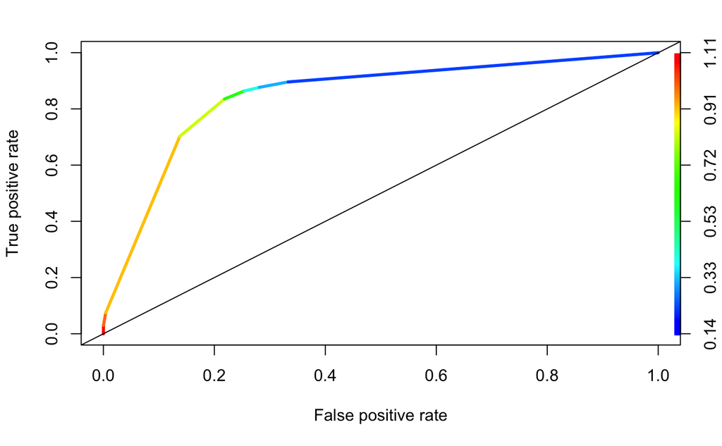

```r
new.roc<-predict(newM, adult_test, type='prob')[,2]
npred<-prediction(new.roc, adult_test$income)
nperfor<-performance(npred, "tpr", "fpr")
plot(nperfor, colorize=T, lwd=3)
abline(0,1)
```

```r
auc<-performance(npred, measure="auc")
```

```r
print(auc@y.values)
```

```
[[1]]
[1] 0.846
```

### f) Diferences between balanced accuracy, sensitivity, specificity, positive predictive value and AUC of the models used in (c) and (e).

#### The sensitivity and specificity depend on the number of observations on each class. Since the training set has decreased, the model can pick up less patterns for the labels, which results in a lower value for the sensitivity.

#### The specificity is higher because there is a more even distribution of the labels in the set. Therefore, there is a greater chance of obtaining the true negatives.

#### The second model has slightly higher area under the curve, so the model is better.

## 2.2 Random Forest

```r
library(randomForest)
library(ggplot2)
set.seed(1122)
```

### a) Create a Random Forest model using the entire training dataset

```r
rmodel<-randomForest(income~., data=adult_train,importance=TRUE)
rpred<-predict(rmodel, adult_test, type="class")
confusionMatrix(rpred, adult_test$income)
```

```
Confusion Matrix and Statistics

          Reference
Prediction <=50K  >50K
     <=50K 10563  1340
     >50K    797  2360

               Accuracy : 0.858
                 95% CI : (0.852, 0.864)
    No Information Rate : 0.754
    P-Value [Acc > NIR] : <2e-16

                  Kappa : 0.597
 Mcnemar's Test P-Value : <2e-16

            Sensitivity : 0.930
            Specificity : 0.638
         Pos Pred Value : 0.887
         Neg Pred Value : 0.748
             Prevalence : 0.754
         Detection Rate : 0.701
   Detection Prevalence : 0.790
      Balanced Accuracy : 0.784

       'Positive' Class : <=50K
```

#### i) The Balanced Accuracy=0.784

#### ii) The Accuracy=0.858

#### iii) Sensitivity=0.930 and Specificity=0.638

#### iv) the class distribution has 11360 observations <=50k and 3700 >50k.

```r
table(adult_test$income)
```

```
<=50K  >50K
11360  3700
```

#### v) It makes sense that the sensitivity is higher than the specificity since there are more observations for the “<=50K” label (positive class) than for the “>50K” (negative class). Since I have more positive observations, the model can pick up more patterns for them, thus resulting in a higher sensitivity.

#### The most important variable for MeanDecreaseAccuracy is the capital gain. The least important one is fnlwgt since it has no effect in the accuracy.

#### The most important variable for MeanDecreaseGini is relationship as it has the highest Gini decrease. In that note, the least important one is the race.

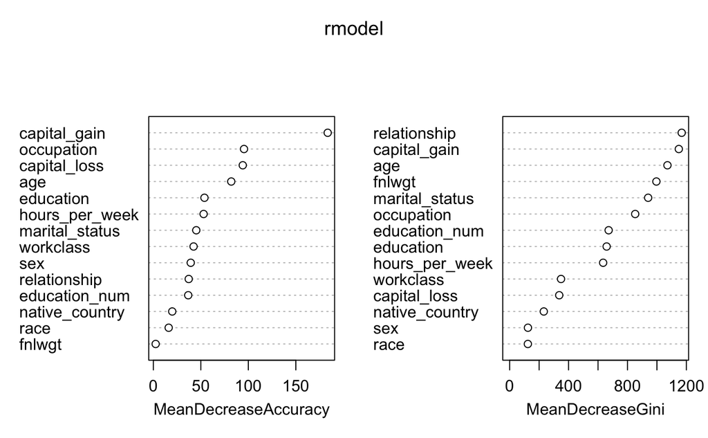

```r
varImpPlot(rmodel)
```

#### vii) The number of variables tried at each split is 3. This is the number of variables used for each subtree.

```r
print(rmodel)
```

```
Call:
 randomForest(formula = income ~ ., data = adult_train, importance = TRUE)
               Type of random forest: classification
                     Number of trees: 500
No. of variables tried at each split: 3

        OOB estimate of  error rate: 13.8%
Confusion matrix:
      <=50K >50K class.error
<=50K 21096 1557      0.0687
>50K   2599 4909      0.3462
```

### b) Find out what is the best value to use for number of predictors to select at each split.

```
mtry = 3  OOB error = 13.86%
Searching left ...
mtry = 2    OOB error = 13.71%
0.011 0.01
Searching right ...
mtry = 4    OOB error = 14.14%
-0.0319 0.01
```

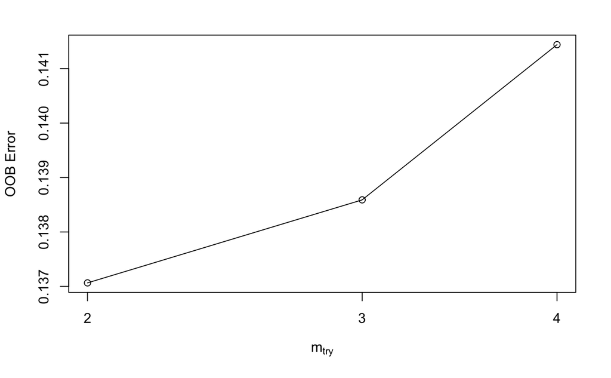

```r
X<-adult_train[,1:14]
Y<-adult_train[,15]
mtry <- tuneRF(X, Y, ntreeTry=500, stepFactor=1.5,improve=0.01, trace=TRUE, plot=TRUE)
```

#### i) The default value of mtry is 3.

#### ii) From the table below, we can see that the lowest error = 0.137 is given by a mtry of 2 and it is the optimal value.

```r
print(mtry)
```

```
      mtry OOBError
2.OOB    2    0.137
3.OOB    3    0.139
4.OOB    4    0.141
```

#### iii) Using the mtry value from ii)

```r
m2<-randomForest(income~., adult_train, importance=TRUE, mtry=2)
p2<-predict(m2, adult_test, type="class")
confusionMatrix(p2, adult_test$income)
```

```
Confusion Matrix and Statistics

          Reference
Prediction <=50K  >50K
     <=50K 10617  1358
     >50K    743  2342

               Accuracy : 0.86
                 95% CI : (0.855, 0.866)
    No Information Rate : 0.754
    P-Value [Acc > NIR] : <2e-16

                  Kappa : 0.601
 Mcnemar's Test P-Value : <2e-16

            Sensitivity : 0.935
            Specificity : 0.633
         Pos Pred Value : 0.887
         Neg Pred Value : 0.759
             Prevalence : 0.754
         Detection Rate : 0.705
   Detection Prevalence : 0.795
      Balanced Accuracy : 0.784

       'Positive' Class : <=50K
```

##### 1. The Balanced Accuracy is 0.784

##### 2. The accuracy of the model is 0.86

##### 3. The sensitivity is 0.935 and the specificity is 0.633

##### 4.

##### The most important variable for MeanDecreaseAccuracy is still capital gain, although the decrease it has is much less than before. The least important variable is still fnlwgt.

##### For MeanDecreaseGini the most important variable now is capital gain. And the least important variable is race.

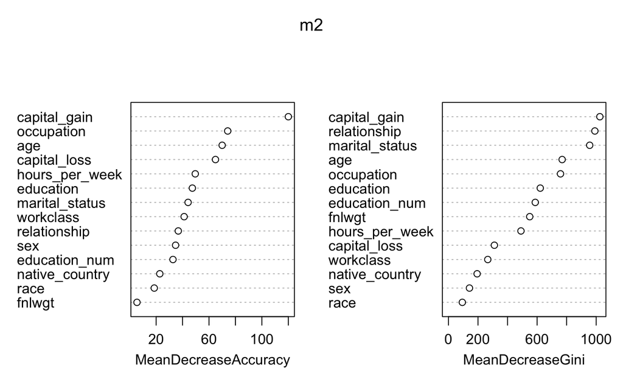

```r
varImpPlot(m2)
```

#### iv) By using 2 predictor variables for the split instead of 3 as in 2.2 a). The obtained values of accuracy, balanced accuracy, sensitivity, specificity do not variate. On the other hand the variable importance in this case for the MeanDecreaseGini changed from relationship to capital_gain as the most optimal.

## 2.3 Association Rules

First, we load the association rules packages and the transaction dataframe.

```r
library(arules)
library(arulesViz)
library(arules)
library(grid)
groceries<-read.transactions(file="../groceries.csv", format="basket", sep=",")
```

### i) How many rules do you get at this support value?

#### A support value of 0.1 is too high and we get 0 rules.

```r
rules<-apriori(groceries)
```

```
Apriori

Parameter specification:
```

|  | confidence | minval | smax | arem | aval | originalSupport | maxtime | support | minlen | maxlen | target | ext |
| --- | --- | --- | --- | --- | --- | --- | --- | --- | --- | --- | --- | --- |
|  | 0.8 | 0.1 | 1 | none | FALSE | TRUE | 5 | 0.1 | 1 | 10 | rules | FALSE |

```
Algorithmic control:
```

|  | filter | tree | heap | memopt | load | sort | verbose |
| --- | --- | --- | --- | --- | --- | --- | --- |
|  | 0.1 | TRUE | TRUE | FALSE | TRUE | 2 | TRUE |

```
Absolute minimum support count: 983

set item appearances ...[0 item(s)] done [0.00s].
set transactions ...[169 item(s), 9835 transaction(s)] done [0.00s].
sorting and recoding items ... [8 item(s)] done [0.00s].
creating transaction tree ... done [0.00s].
checking subsets of size 1 2 done [0.00s].
writing ... [0 rule(s)] done [0.00s].
creating S4 object  ... done [0.00s].
```

```r
summary(rules)
```

```
set of 0 rules
```

### ii) Manipulate the support value so you get at least 400 rules

#### With a support=0.001 we get 410 rules.

```r
rules<-apriori(groceries, parameter=list(supp=0.001))
```

```
Apriori

Parameter specification:
```

|  | confidence | minval | smax | arem | aval | originalSupport | maxtime | support | minlen | maxlen | target | ext |
| --- | --- | --- | --- | --- | --- | --- | --- | --- | --- | --- | --- | --- |
|  | 0.8 | 0.1 | 1 | none | FALSE | TRUE | 5 | 0.001 | 1 | 10 | rules | FALSE |

```
Algorithmic control:
```

|  | filter | tree | heap | memopt | load | sort | verbose |
| --- | --- | --- | --- | --- | --- | --- | --- |
|  | 0.1 | TRUE | TRUE | FALSE | TRUE | 2 | TRUE |

```
Absolute minimum support count: 9

set item appearances ...[0 item(s)] done [0.00s].
set transactions ...[169 item(s), 9835 transaction(s)] done [0.00s].
sorting and recoding items ... [157 item(s)] done [0.00s].
creating transaction tree ... done [0.00s].
checking subsets of size 1 2 3 4 5 6 done [0.02s].
writing ... [410 rule(s)] done [0.00s].
creating S4 object  ... done [0.00s].
```

```r
summary(rules)
```

```
set of 410 rules

rule length distribution (lhs + rhs):sizes
  3   4   5   6
 29 229 140  12

   Min. 1st Qu.  Median    Mean 3rd Qu.    Max.
   3.00    4.00    4.00    4.33    5.00    6.00

summary of quality measures:
    support          confidence         lift           count
 Min.   :0.00102   Min.   :0.800   Min.   : 3.13   Min.   :10.0
 1st Qu.:0.00102   1st Qu.:0.833   1st Qu.: 3.31   1st Qu.:10.0
 Median :0.00122   Median :0.846   Median : 3.59   Median :12.0
 Mean   :0.00125   Mean   :0.866   Mean   : 3.95   Mean   :12.3
 3rd Qu.:0.00132   3rd Qu.:0.909   3rd Qu.: 4.34   3rd Qu.:13.0
 Max.   :0.00315   Max.   :1.000   Max.   :11.24   Max.   :31.0

mining info:
```

|  | data | ntransactions | support | confidence |
| --- | --- | --- | --- | --- |
|  | groceries | 9835 | 0.001 | 0.8 |

### iii) Which item is the most frequently bought and what is its frequency?

#### The “whole milk” is the most frequently bought item, with a frequency of 0.256

```r
items<-sort(itemFrequency(groceries), decreasing=T)
items[1]
```

```
whole milk
     0.256
```

### iv) Which item is the least frequently bought and what is its frequency?

#### The least frequently bought item is “rubbing alcohol” with a frequency of 0.00102.

```r
last<-sort(itemFrequency(groceries), decreasing=F)
last<-last[last>=0.001]
last[1]
```

```
rubbing alcohol
        0.00102
```

### v) What are the top 5 rules, sorted by support?

```r
inspect(head(rules, n=5, by="support"))
```

|  | lhs |  | rhs | support | confidence | lift | count |
| --- | --- | --- | --- | --- | --- | --- | --- |
| [1] | {citrus fruit,root vegetables,tropical fruit,whole milk} | => | {other vegetables} | 0.00315 | 0.886 | 4.58 | 31 |
| [2] | {curd,domestic eggs,other vegetables} | => | {whole milk} | 0.00285 | 0.824 | 3.22 | 28 |
| [3] | {curd,hamburger meat} | => | {whole milk} | 0.00254 | 0.806 | 3.16 | 25 |
| [4] | {herbs,rolls/buns} | => | {whole milk} | 0.00244 | 0.800 | 3.13 | 24 |
| [5] | {herbs,tropical fruit} | => | {whole milk} | 0.00234 | 0.821 | 3.21 | 23 |

### vi) What are the top 5 rules, sorted by confidence?

```r
inspect(head(rules, n=5, by="confidence"))
```

|  | lhs |  | rhs | support | confidence | lift | count |
| --- | --- | --- | --- | --- | --- | --- | --- |
| [1] | {rice,sugar} | => | {whole milk} | 0.00122 | 1 | 3.91 | 12 |
| [2] | {canned fish,hygiene articles} | => | {whole milk} | 0.00112 | 1 | 3.91 | 11 |
| [3] | {butter,rice,root vegetables} | => | {whole milk} | 0.00102 | 1 | 3.91 | 10 |
| [4] | {flour,root vegetables,whipped/sour cream} | => | {whole milk} | 0.00173 | 1 | 3.91 | 17 |
| [5] | {butter,domestic eggs,soft cheese} | => | {whole milk} | 0.00102 | 1 | 3.91 | 10 |

### vii) What are the bottom 5 rules, sorted by support?

```r
inspect(tail(rules, n=5, by="support"))
```

|  | lhs |  | rhs | support | confidence | lift | count |
| --- | --- | --- | --- | --- | --- | --- | --- |
| [1] | {oil,other vegetables,tropical fruit,whole milk,yogurt} | => | {root vegetables} | 0.00102 | 0.909 | 8.34 | 10 |
| [2] | {butter,domestic eggs,other vegetables,tropical fruit,yogurt} | => | {whole milk} | 0.00102 | 0.909 | 3.56 | 10 |
| [3] | {butter,domestic eggs,tropical fruit,whole milk,yogurt} | => | {other vegetables} | 0.00102 | 0.833 | 4.31 | 10 |
| [4] | {citrus fruit,other vegetables,root vegetables,whipped/sour cream,yogurt} | => | {whole milk} | 0.00102 | 0.833 | 3.26 | 10 |
| [5] | {citrus fruit,root vegetables,whipped/sour cream,whole milk,yogurt} | => | {other vegetables} | 0.00102 | 0.909 | 4.70 | 10 |

### viii) What are the bottom 5 rules, sorted by confidence?

```r
inspect(tail(rules, n=5, by="confidence"))
```

|  | lhs |  | rhs | support | confidence | lift | count |
| --- | --- | --- | --- | --- | --- | --- | --- |
| [1] | {pip fruit,tropical fruit,whipped/sour cream,whole milk} | => | {other vegetables} | 0.00163 | 0.8 | 4.13 | 16 |
| [2] | {citrus fruit,other vegetables,sausage,whipped/sour cream} | => | {whole milk} | 0.00122 | 0.8 | 3.13 | 12 |
| [3] | {citrus fruit,sausage,whipped/sour cream,whole milk} | => | {other vegetables} | 0.00122 | 0.8 | 4.13 | 12 |
| [4] | {citrus fruit,tropical fruit,whipped/sour cream,yogurt} | => | {whole milk} | 0.00122 | 0.8 | 3.13 | 12 |
| [5] | {rolls/buns,root vegetables,tropical fruit,whipped/sour cream} | => | {other vegetables} | 0.00122 | 0.8 | 4.13 | 12 |